# Week 5: The Bootstrap

STAT 536 — Statistical Computing

Soumojit Das

Fall 2026

# From Known $F$ to Unknown $F$

## The Problem Changes

In weeks 1 through 4, every method started from a known distribution $F$. Monte Carlo integration drew $X_1, \ldots, X_n \iid F$ and averaged; sampling methods (inverse transform, accept-reject, ratio of uniforms) each required $F$ or its density. The error rate was $O(n^{-1/2})$, dimension-free, and the CLT gave a confidence interval.

From here, $F$ is unknown and the sample $X_1, \ldots, X_n$ is all we have. The goal is the same: estimate a parameter $\theta = T(F)$ and quantify how accurate the estimate is. The tool changes: replace $F$ with the empirical distribution $\hat F_n$.

## The Bootstrap as Week-1 Monte Carlo

Sampling from $\hat F_n$ means drawing indices $U_1, \ldots, U_n \iid \Uniform\{1, \ldots, n\}$ and setting $X_i^* = X_{U_i}$: the discrete inverse transform from week 2, applied to a uniform on $n$ atoms. The result is a sample of size $n$ drawn with replacement from the data.

Two errors, one new and one familiar:

1. **Statistical error:** using $\hat F_n$ in place of $F$ (fixed by the sample size $n$)
2. **Monte Carlo error:** using $B$ resamples instead of all possible ($O(B^{-1/2})$, under our control)

Recall the $n^{-1/2}$ rate from week 1? The Monte Carlo error obeys the same rate in $B$.

# The Bootstrap Principle

## The Statistical Inference Problem

**The Fundamental Challenge.** Given data $X_1, \ldots, X_n \sim F$ and statistic $\hat\theta = T(X_1, \ldots, X_n)$:

- We want: distribution of $\hat\theta - \theta$ where $\theta = T(F)$
- We have: single realization of $\hat\theta$
- Classical approach: derive analytically (often impossible)
- Monte Carlo approach: simulate from $F$ (but $F$ is unknown)

$T(F)$: the rule $T$ applied to $F$ itself (the mean of $F$, the correlation under $F$), as $\hat\theta$ applies it to the sample.

## The Bootstrap Insight

**The Bootstrap Insight (Efron, 1979).** Replace the unknown $F$ with the empirical distribution $\hat{F}_n$:

$$\hat{F}_n(x) = \frac{1}{n}\sum_{i=1}^n \mathbf{1}\{X_i \leq x\}$$

where $\mathbf{1}\{A\}$ is the indicator function, equal to $1$ when $A$ holds and $0$ otherwise. Then simulate from $\hat{F}_n$ to approximate the sampling distribution.

## Two Worlds

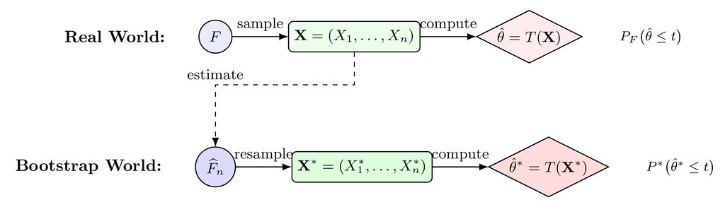

“The population is to the sample as the sample is to the bootstrap samples.”

## The Bootstrap Approximation

For smooth functionals $T$:

$$\sqrt{n}(\hat\theta - \theta) \;\approx_{d}\; \sqrt{n}(\hat\theta^* - \hat\theta)$$

where the left side is distributed under $P_F$ (over samples from $F$), the right side under $P^*$ (over resamples, data fixed); $\approx_d$: the two distributions are close.

Essentially, this says that the distribution of the recentered, rescaled statistic in the real world is close to the distribution of the same quantity in the bootstrap world.

## The Law-School Data

**The study.** A study of admission practices covered $N = 82$ American law schools. For each school it recorded two averages over the class entering in 1973: the mean LSAT score and the mean undergraduate GPA (Efron and Tibshirani, 1993).

**The sample.** We observe a random sample of $n = 15$ of these schools. Each column is one school:

| School | 1 | 2 | 3 | 4 | 5 | 6 | 7 | 8 | 9 | 10 | 11 | 12 | 13 | 14 | 15 |
| --- | --- | --- | --- | --- | --- | --- | --- | --- | --- | --- | --- | --- | --- | --- | --- |
| LSAT | 576 | 635 | 558 | 578 | 666 | 580 | 555 | 661 | 651 | 605 | 653 | 575 | 545 | 572 | 594 |
| GPA | 3.39 | 3.30 | 2.81 | 3.03 | 3.44 | 3.07 | 3.00 | 3.43 | 3.36 | 3.13 | 3.12 | 2.74 | 2.76 | 2.88 | 2.96 |

The unit of observation is a school. One point is one pair (mean LSAT, mean GPA), and the two coordinates of a pair belong together.

## The Question We Ask of These Data

**The parameter.** How strongly do the two admission measures move together across law schools? We measure this by the correlation between LSAT and GPA over all $82$ schools, $\theta = T(F)$, where $F$ is the joint distribution of the pair.

**The estimate.** The sample correlation of the $15$ pairs is $\hat\theta = T(\hat F_n) = 0.776$.

**The problem.** How far from $\theta$ could an estimate from $15$ points be? For a mean the answer is $S/\sqrt{n}$. For a correlation the textbook formula $(1 - \hat\theta^2)/\sqrt{n - 3} = 0.115$ assumes bivariate normal data, and we have no reason to believe that here.

**Why this dataset.** We have the whole population of $82$ schools, so we can check how well the bootstrap works against the truth. In practice we would not know $\theta$ or the true sampling distribution.

## The Sample within Its Population

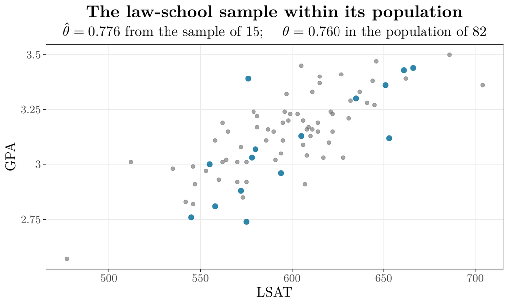

The sample correlation is $\hat\theta = 0.776$, and the population value is $\theta = 0.760$. How accurate is $\hat\theta$?

## The Nonparametric Bootstrap Algorithm

**Input:** Data $\mathbf{X} = (X_1, \ldots, X_n)$, the rule $T$ (so $\hat\theta = T(X_1, \ldots, X_n)$), number of replications $B$.

**Output:** Bootstrap replicates $\{\hat\theta^{*(1)}, \ldots, \hat\theta^{*(B)}\}$.

**For** $b = 1$ to $B$:

1. Generate $U_1, \ldots, U_n \sim \Uniform\{1, 2, \ldots, n\}$
2. Set $X_i^* = X_{U_i}$ for $i = 1, \ldots, n$ (sampling with replacement)
3. Compute $\hat\theta^{*(b)} = T(X_1^*, \ldots, X_n^*)$

Steps 1 and 2 are the discrete inverse transform of week 2. In R:

```r
theta_boot <- numeric(B)
for (b in seq_len(B)) {
  i <- sample(n, n, replace = TRUE)
  theta_boot[b] <- cor(lsat[i], gpa[i])
}
```

## What We Can Estimate

- **Standard Error:** $\widehat{\text{SE}}(\hat\theta) = \sqrt{\frac{1}{B-1}\sum_{b=1}^B (\hat\theta^{*(b)} - \bar\theta^*)^2}$
- **Bias:** $\widehat{\text{Bias}}(\hat\theta) = \bar\theta^* - \hat\theta$ where $\bar\theta^* = \frac{1}{B}\sum_{b=1}^B \hat\theta^{*(b)}$
- **Distribution:** $P^*(\hat\theta^* \leq t) \approx \frac{1}{B}\sum_{b=1}^B \mathbf{1}\{\hat\theta^{*(b)} \leq t\}$, the proportion of replicates at or below $t$

## Notation

| Symbol | Meaning |
| --- | --- |
| $F$; $\hat F_n$ | the unknown distribution of the data; the empirical distribution, mass $1/n$ on each $X_i$ |
| $\theta = T(F)$; $\hat\theta = T(\hat F_n)$ | the parameter; the same rule $T$ on the data |
| $X_1^*, \ldots, X_n^*$; $\hat\theta^*$; $\hat\theta^{*(b)}$ | a resample, $n$ draws with replacement; the rule $T$ on it; on resample $b$, $b = 1, \ldots, B$ |
| $P_F$, $\E_F$, $\Var_F$ | probability, mean, variance over samples from $F$ |
| $P^*$, $\E^*$, $\Var^*$ | probability, mean, variance over the resampling (the index draws), data fixed |
| $\widehat{\text{SE}}$; $\widehat{\text{SE}}^{*(b)}$ | the standard-error rule on the data; on resample $b$ |

A star means computed from a resample; $(b)$ says which one.

## The Sampling Distribution of $\hat\theta$

**$\theta$ is a fixed number.** It has no distribution. For the law schools $\theta = 0.760$, the correlation computed from all $82$ schools.

**$\hat\theta$ is random, because the sample is.** Another sample of $15$ schools gives another $\hat\theta$. The distribution of $\hat\theta$ over repeated samples from $F$ is the **sampling distribution** of $\hat\theta$. The standard error $\text{SE}_F(\hat\theta)$ is the standard deviation of that distribution.

**In practice** we have one sample and one $\hat\theta$, so we never see the sampling distribution. Here we have the whole population, so we can build it: draw $15$ schools from the $82$, compute $\hat\theta$, and repeat $100000$ times. Each draw picks one of the $82$ schools with probability $1/82$, independently of the others, so a school can be drawn twice. This is $X_1, \ldots, X_n \iid F$ with $F$ the population of $82$ schools.

**The bootstrap** runs the same recipe with the $15$ schools we have in place of the $82$: draw $15$ from the $15$, compute $\hat\theta^*$, repeat $B$ times.

## Bootstrap and Sampling Distributions

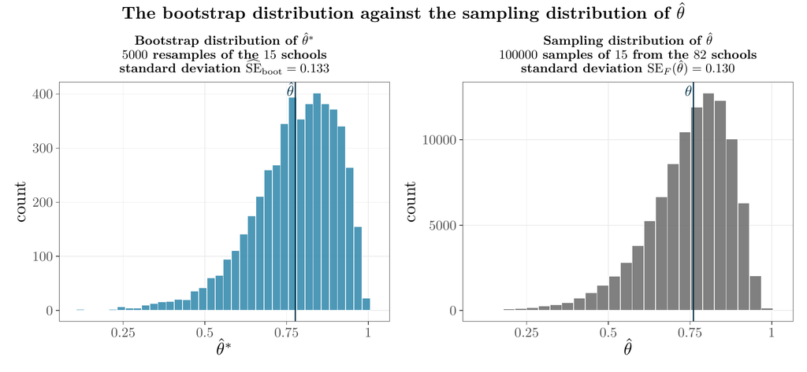

Left: built from the $15$ schools we have. Right: built from all $82$, which is possible only here. The centers are $\hat\theta$ and $\theta$, so the bootstrap is asked to match the spread and the shape: $\widehat{\text{SE}}_{\text{boot}} = 0.133$ against $\text{SE}_F(\hat\theta) = 0.130$.

## How Many Bootstrap Samples

Total possible bootstrap samples: $\binom{2n-1}{n} = \tfrac{1}{2}\binom{2n}{n} \approx \frac{4^n}{2\sqrt{\pi n}}$. For $n = 10$: $\binom{19}{10} = 92{,}378$.

**Two sources of error.**

1. **Statistical error:** using $\hat{F}_n$ instead of $F$ (fixed by $n$)
2. **Monte Carlo error:** using $B$ samples instead of all possible ($O(B^{-1/2})$, under our control)

**Guidelines (Efron and Tibshirani, 1993).** $B = 200$ for standard errors, $1000$–$2000$ for confidence intervals, $\geq 10{,}000$ for p-values. Increase $B$ until results stabilize.

## Monte Carlo Error in $B$

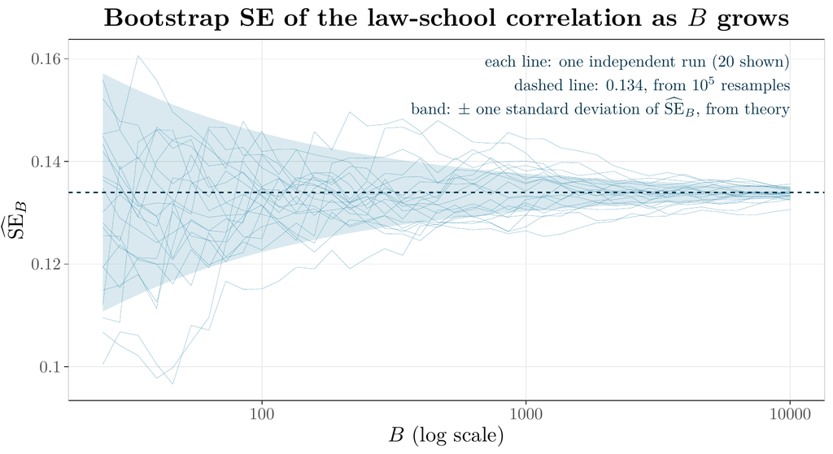

Each line is one bootstrap run on the same $15$ law schools, and the runs differ only in their random resamples. Across runs $\widehat{\text{SE}}_B$ has standard deviation $0.0082$ at $B = 200$ and $0.0027$ at $B = 2000$: ten times the work, about $\sqrt{10}$ times the precision. Recall the same rate for $n$ in week 1?

## Consistency for the Mean

**Theorem (Bootstrap Consistency for the Mean).** Let $\hat\theta = \bar{X}_n$ and assume $\Var_F(X_1) = \sigma^2 < \infty$. Then:

$$\sup_t \left|P_F\!\left(\frac{\sqrt{n}(\bar{X}_n - \mu)}{\sigma} \leq t\right) - P^*\!\left(\frac{\sqrt{n}(\bar{X}_n^* - \bar{X}_n)}{S_n} \leq t\right)\right| \xrightarrow{P} 0$$

where $S_n^2 = \frac{1}{n-1}\sum_{i=1}^n (X_i - \bar{X}_n)^2$; $\mu = \E_F X_1$; $\bar X_n^*$: the mean of one resample; $P^*$: over the resampling, data fixed.

Essentially, this says the bootstrap distribution of the standardized mean converges uniformly to the true sampling distribution.

**Proof idea.** The CLT gives $\sqrt{n}(\bar X_n - \mu)/\sigma \xrightarrow{d} \Normal(0,1)$. Given the data, $X_1^*, \ldots, X_n^*$ are iid draws from $\hat F_n$, a distribution with mean $\bar X_n$ and variance $\frac{n-1}{n}S_n^2$, and $S_n^2$ settles at $\sigma^2$ by the law of large numbers. A CLT in the bootstrap world then gives $\sqrt{n}(\bar X_n^* - \bar X_n)/S_n \xrightarrow{d} \Normal(0,1)$ as well. We have two distribution functions converging to the same continuous limit, and convergence to a continuous limit is uniform in $t$ (Polya’s theorem), thus the supremum of their difference vanishes.

## Where the Bootstrap Fails

**Example: $\hat\theta = X_{(n)} = \max\{X_1, \ldots, X_n\}$ for $X_i \sim \Uniform(0, \theta)$.**

**True distribution.** $P(X_{(n)} \leq x) = (x/\theta)^n$ for $0 \leq x \leq \theta$, so $P(n(\theta - X_{(n)})/\theta > t) = (1 - t/n)^n \to e^{-t}$. Thus $n(\theta - X_{(n)})/\theta \xrightarrow{d} \Exp(1)$, a continuous distribution.

**Bootstrap distribution.** Each $X_i^*$ is drawn independently from $\{X_1, \ldots, X_n\}$, so $P(X_i^* = X_{(n)}) = 1/n$. The bootstrap maximum $X^*_{(n)} = \max_i X_i^*$ equals $X_{(n)}$ when at least one draw hits it: $P(X^*_{(n)} = X_{(n)}) = 1 - (1 - 1/n)^n \to 1 - e^{-1} \approx 0.632$. Thus the bootstrap analogue $n(X_{(n)} - X^*_{(n)})/X_{(n)}$ equals zero with probability about $0.632$, while the limit it should reproduce is continuous and puts no mass at zero.

## The Failure in a Picture

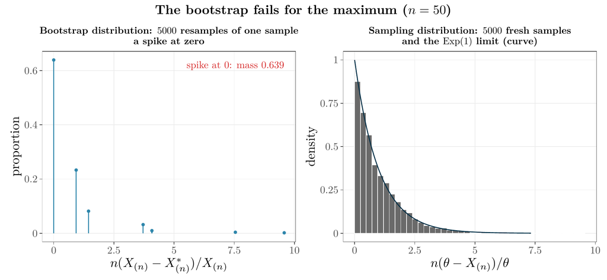

With $n = 50$, a proportion $0.639$ of the bootstrap maxima equal $X_{(n)}$. The theory gives $1 - (1 - 1/n)^n = 0.636$.

## The Bootstrap Works for Smooth Functionals

**Smooth Functionals**

The bootstrap works for smooth functionals of $F$. When $T$ depends on a single extreme order statistic, the discrete support of $\hat F_n$ prevents the bootstrap from approximating a continuous limit.

- The bootstrap replaces $F$ with $\hat F_n$ and runs Monte Carlo from there: the same $O(B^{-1/2})$ convergence, the same averaging, with the data standing in for the population.
- Two errors: statistical (from $\hat F_n$ in place of $F$, controlled by $n$) and Monte Carlo (from $B$ resamples, controlled by $B$).
- For smooth functionals of $F$, the bootstrap distribution converges to the true sampling distribution.

# What a Confidence Interval Promises

## A Confidence Interval Is a Procedure

**Definition.** A $1-\alpha$ confidence interval for $\theta$ is a pair of statistics $L(\mathbf{X}) \leq U(\mathbf{X})$ with

$$P_F\bigl(L(\mathbf{X}) \leq \theta \leq U(\mathbf{X})\bigr) = 1 - \alpha \quad \text{for every } F \text{ in the model.}$$

The probability is over the sample $\mathbf{X}$. The parameter $\theta$ is a fixed number. The endpoints $L$ and $U$ are the random quantities.

Essentially, this says that if we repeated the whole experiment many times and built the interval each time, a fraction $1 - \alpha$ of those intervals would contain $\theta$.

**After the data are in.** The realized interval, say $(0.46, 0.96)$, either contains $\theta$ or it does not. The $95\%$ describes the procedure that produced it.

## One Procedure, 100 Samples

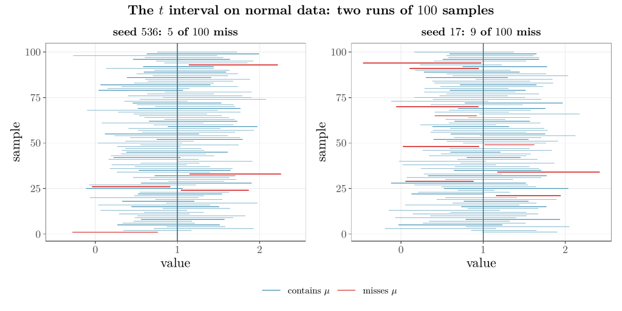

Each segment is the interval $\bar X \pm t_{n-1,\,0.975}\, S/\sqrt{n}$ from a fresh normal sample of $n = 15$ ($S$: sample standard deviation; $t_{n-1,\,0.975}$: the $0.975$ quantile of $t_{n-1}$), an exact $95\%$ procedure. The two runs miss $5$ and $9$ times in $100$: the count is a $\Bin(100, 0.05)$ draw, and the $95\%$ is the long-run fraction. In practice we hold one segment and never learn its color.

## Nominal and Actual Coverage

**Nominal coverage** is the $1 - \alpha$ that the formula promises under its assumptions. **Actual coverage** is $P_F(L \leq \theta \leq U)$ under the distribution that generated the data, at the sample size we have. **Coverage error** is the difference between the two.

**Exact**

Actual equals nominal at every $n$. The $t$ interval for normal data is one example, and the next slide gives another.

**Conservative**

Actual exceeds nominal. The claim holds, and the interval is wider than it needs to be.

**Liberal**

Actual falls short of nominal. The interval claims more than it delivers.

A **pivot** is a function of the data and the parameter whose distribution does not depend on anything unknown. The $t$ interval is exact for normal data because its pivot $(\bar X - \mu)/(S/\sqrt{n})$ has a $t_{n-1}$ distribution, whatever $\mu$ and $\sigma$ are. A simulation of $20000$ normal samples of $n = 15$ agrees: $0.950$. For any other $F$ the $t_{n-1}$ distribution is an approximation, and the actual coverage is whatever it turns out to be.

## An Exact Interval for Exponential Data

Let $X_1, \ldots, X_n$ be iid exponential with mean $\mu$. Recall from week 2 that a sum of $n$ independent exponentials is a Gamma variable, and that $\chi^2_k = \Gam(k/2, 1/2)$? Rescaling the sum gives a pivot:

$$\frac{2n\bar X}{\mu} = \frac{2}{\mu}\sum_{i=1}^n X_i \sim \chi^2_{2n}.$$

Its distribution is known and free of $\mu$. Thus $P\bigl(\chi^2_{2n,\,0.025} \leq 2n\bar X/\mu \leq \chi^2_{2n,\,0.975}\bigr) = 0.95$, and solving the two inequalities for $\mu$ gives an exact $95\%$ interval:

$$\left[\frac{2n\bar X}{\chi^2_{2n,\,0.975}},\; \frac{2n\bar X}{\chi^2_{2n,\,0.025}}\right].$$

Essentially, this says the exponential model hands us a pivot with a known distribution, as the normal model does. The interval is asymmetric about $\bar X$: at $n = 15$ it runs from $0.64\,\bar X$ to $1.79\,\bar X$.

## Same Samples, Two Intervals

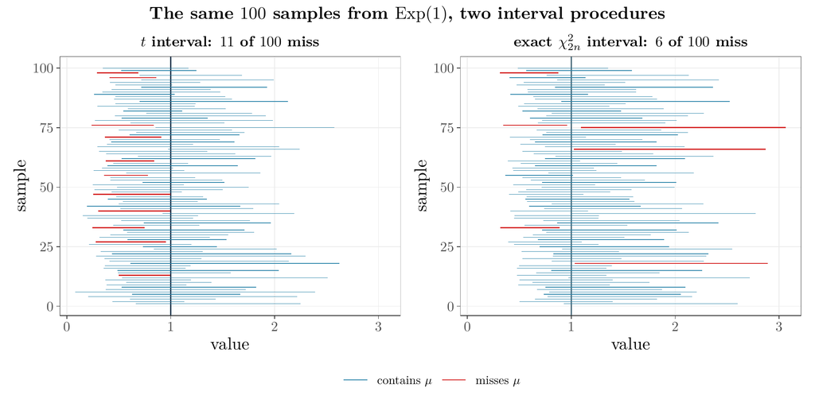

The same $100$ exponential samples in both panels, $n = 15$. The $t$ interval is what we would compute without knowing $F$. The exact interval needs the exponential model. Over $20000$ samples the $t$ interval covers $0.912$ and the exact interval $0.951$.

## Both Sides of an Interval

An equal-tailed two-sided interval makes two promises:

$$P_F(\theta < L) = \alpha/2 \qquad \text{and} \qquad P_F(\theta > U) = \alpha/2.$$

For the exponential data, the $t$ interval leaves $\mu$ below its lower limit with probability $0.005$ and above its upper limit with probability $0.084$, each nominally $0.025$. The total is off, and the split is off by more. The exact interval gives $0.025$ and $0.024$.

In the picture, all 11 misses of the $t$ interval lie entirely below $\mu$, and they are short. For a right-skewed $F$ a sample with a small $\bar X$ tends to have a small $S$ as well, so its interval is shifted down and too short at once.

A one-sided statement, such as “the mean reduction is at least $L$”, rests on one of these two probabilities alone. This is where interval methods differ most, and it is the scale on which their accuracy is stated.

## Coverage Is Estimated by Simulation

Actual coverage is a probability under $F$, so we estimate it by Monte Carlo:

1. Choose an $F$ with a known $\theta$, a sample size $n$, and an interval method.
2. For $r = 1, \ldots, R$: draw a dataset from $F$, build the interval $[L_r, U_r]$, record $C_r = \mathbf{1}\{L_r \leq \theta \leq U_r\}$.
3. Report $\hat C = \frac{1}{R}\sum_{r=1}^R C_r$ with standard error $\sqrt{\hat C(1 - \hat C)/R}$.

Recall the Monte Carlo standard error of a proportion from week 1? With $R = 2000$ and $\hat C \approx 0.95$ it is about $0.005$. With $R = 100$ it is about $0.022$: the two runs of 100 normal samples were both ordinary, and 100 intervals cannot tell a coverage of $0.95$ from one of $0.91$. The coverage numbers on the last slides use $R = 20000$.

Coverage is a property of a method, under a given $F$ and $n$. A single dataset cannot reveal it, because a single interval either covers or it does not. When the interval is a bootstrap interval the simulation has two layers: $R$ datasets, and $B$ resamples inside each.

## What We Ask of the Bootstrap

- Exactness came from knowing the distribution of a pivot: $t_{n-1}$ under the normal model, $\chi^2_{2n}$ under the exponential model. Both require knowing $F$ up to its parameters, and in practice we do not.
- The bootstrap estimates the distribution of the pivot, or of $\hat\theta$ itself, from the sample. No formula for that distribution is needed.
- A bootstrap interval is judged the way any interval is judged: by its actual coverage, on each side, at the sample sizes we face.
- The benchmark is the interval we would otherwise report, the $t$ interval at $0.912$ for the exponential mean. No bootstrap interval is exact. We ask how much of the coverage error it removes, and on which side.
- The four constructions that follow differ in what they bootstrap, and their coverage differs accordingly.

# Bootstrap Confidence Intervals

## The Percentile Interval

**Percentile Method.** Use the bootstrap distribution quantiles directly:

$$\text{CI}_{\text{perc}} = \left[\hat\theta^*_{(\alpha/2)},\; \hat\theta^*_{(1-\alpha/2)}\right]$$

where $\hat\theta^*_{(\alpha)}$ is the $\alpha$-quantile of $\{\hat\theta^{*(1)}, \ldots, \hat\theta^{*(B)}\}$.

**Justification.** The interval is exact when some monotone transformation $\phi$ makes $\phi(\hat\theta)$ normal, centered at $\phi(\theta)$, with constant variance. We never need to know $\phi$.

**Weakness.** First-order accurate: one-sided coverage error $O(n^{-1/2})$, with no correction for bias or skewness.

**Strength.** Respects monotone transformations: if $\phi$ is monotone, $\phi(\text{CI}_{\text{perc}}(\hat\theta)) = \text{CI}_{\text{perc}}(\phi(\hat\theta))$ (two-line argument in the notes).

## The Basic (Pivotal) Interval

**Derivation.** If $P(a \leq \hat\theta - \theta \leq b) = 1 - \alpha$, rearranging gives $P(\hat\theta - b \leq \theta \leq \hat\theta - a) = 1 - \alpha$. We estimate the quantiles $a$ and $b$ of $\hat\theta - \theta$ by those of $\hat\theta^* - \hat\theta$, that is $a \approx \hat\theta^*_{(\alpha/2)} - \hat\theta$ and $b \approx \hat\theta^*_{(1-\alpha/2)} - \hat\theta$. Thus

$$\text{CI}_{\text{basic}} = \left[2\hat\theta - \hat\theta^*_{(1-\alpha/2)},\; 2\hat\theta - \hat\theta^*_{(\alpha/2)}\right]$$

**Overshoot intuition.** If bootstrap samples overshoot by amount $d$, we expect the same overshoot in the real world, so we correct by $-d$.

## The Bootstrap-t Idea

**The idea.** Mimic the classical $t$-statistic approach:

$$t = \frac{\hat{\theta} - \theta}{\widehat{\text{SE}}(\hat{\theta})}$$

We do not know the distribution of $t$, so we bootstrap it. The bootstrap studentized statistic is

$$t^{*(b)} = \frac{\hat{\theta}^{*(b)} - \hat{\theta}}{\widehat{\text{SE}}^{*(b)}}$$

where $\theta$: the parameter; $\hat\theta$: its estimate from the data; $\widehat{\text{SE}}(\hat\theta)$: its estimated standard error; the $^{*(b)}$ versions: defined on the next slide.

This requires computing $\widehat{\text{SE}}^{*(b)}$ for each bootstrap sample.

## Defining $\hat\theta^{*(b)}$ and $\widehat{\mathrm{SE}}^{*(b)}$

$\hat\theta = T(X_1, \ldots, X_n)$; $\widehat{\text{SE}}(\cdot)$: a rule that turns a dataset into a standard-error estimate for $T$ (a formula, the jackknife, or an inner bootstrap), so $\widehat{\text{SE}}(\hat\theta) = \widehat{\text{SE}}(X_1, \ldots, X_n)$. On the $b$-th resample $X_1^{*(b)}, \ldots, X_n^{*(b)}$, $b = 1, \ldots, B$, the same two rules:

$$\hat\theta^{*(b)} = T\bigl(X_1^{*(b)}, \ldots, X_n^{*(b)}\bigr), \qquad \widehat{\text{SE}}^{*(b)} = \widehat{\text{SE}}\bigl(X_1^{*(b)}, \ldots, X_n^{*(b)}\bigr).$$

For the mean, $\widehat{\text{SE}}^{*(b)} = S^{*(b)}/\sqrt{n}$, $S^{*(b)}$ the standard deviation of the resample. The distribution of $t$ is the unknown; the $t^{*(b)}$ are draws from its bootstrap estimate.

## The Bootstrap-t Algorithm

1. Compute $\hat\theta = T(X_1, \ldots, X_n)$ and $\widehat{\text{SE}}$ (from a formula, the jackknife, or the bootstrap)
2. For $b = 1, \ldots, B$: resample with replacement, compute $\hat\theta^{*(b)}$ and $\widehat{\text{SE}}^{*(b)}$, form $t^{*(b)} = (\hat\theta^{*(b)} - \hat\theta)/\widehat{\text{SE}}^{*(b)}$
3. Confidence interval: $\left[\hat\theta - t^*_{(1-\alpha/2)} \cdot \widehat{\text{SE}},\; \hat\theta - t^*_{(\alpha/2)} \cdot \widehat{\text{SE}}\right]$, where $t^*_{(\alpha)}$ is the $\alpha$-quantile of $\{t^{*(1)}, \ldots, t^{*(B)}\}$

**Computing $\widehat{\text{SE}}^{*(b)}$.** Use a closed-form formula when one exists ($S^*/\sqrt{n}$ for the mean, $S^*$ the standard deviation of the resample; the square roots of the diagonal of $\hat\sigma^{*2}(\mathbf{X}^{*\top}\mathbf{X}^*)^{-1}$ for regression coefficients, $\hat\sigma^{*2}$ and $\mathbf{X}^*$ the residual variance and design matrix of the refit on the resample). Otherwise, use the jackknife (next week) on the bootstrap sample: $n$ leave-one-out evaluations instead of a nested bootstrap. An inner bootstrap of $B'$ resamples from each bootstrap sample is the last resort: total cost $B \times B'$.

## Studentization

**Why studentize.** The basic interval assumes $\hat\theta - \theta$ is pivotal (its distribution does not depend on $F$). This fails when:

- Variance depends on the parameter (e.g., Poisson, Binomial)
- Sample size is small
- Distribution is skewed

By dividing by $\widehat{\text{SE}}^{*(b)}$, the bootstrap-t accounts for nonconstant variance and achieves second-order accuracy: $O(n^{-1})$ vs $O(n^{-1/2})$ for one-sided limits.

**The quantile flip.** The quantiles reverse in the confidence interval: if $t^*$ is large and positive, $\theta$ is probably smaller than $\hat\theta$, so the upper quantile sets the lower bound.

## Coverage Accuracy

**Theorem (Hall, 1988).** Under regularity conditions, the one-sided coverage error is:

- Percentile and Basic: $O(n^{-1/2})$
- Bootstrap-t and BCa: $O(n^{-1})$

Essentially, this says each endpoint of a bootstrap-t or BCa interval misses its nominal level by an amount of order $1/n$, against $1/\sqrt{n}$ for the percentile and basic intervals.

**Two-sided intervals.** In an equal-tailed two-sided percentile or basic interval the leading errors of the two endpoints cancel, so all four methods have two-sided coverage error $O(n^{-1})$ (Hall, 1988). The difference shows in each endpoint separately, and in coverage at small $n$.

## BCa Preview

**BCa (Bias-Corrected and Accelerated).** Adjusts percentile endpoints for bias and skewness:

$$\text{CI}_{\text{BCa}} = \left[\hat\theta^*_{(\alpha_1)},\; \hat\theta^*_{(\alpha_2)}\right]$$

where

$$\alpha_1 = \Phi\!\left(\hat{z}_0 + \frac{\hat{z}_0 + z_{\alpha/2}}{1 - \hat{a}(\hat{z}_0 + z_{\alpha/2})}\right), \qquad \alpha_2 = \Phi\!\left(\hat{z}_0 + \frac{\hat{z}_0 + z_{1-\alpha/2}}{1 - \hat{a}(\hat{z}_0 + z_{1-\alpha/2})}\right)$$

where $\Phi$ is the standard normal CDF and $z_\alpha = \Phi^{-1}(\alpha)$.

**The corrections.** $\hat{z}_0 = \Phi^{-1}\bigl(\#\{\hat\theta^{*(b)} < \hat\theta\}/B\bigr)$ corrects for median bias of the bootstrap distribution. $\hat{a}$ corrects for the rate of change of the standard error (acceleration). When $\hat z_0 = \hat a = 0$, BCa reduces to the percentile interval. Computed next week with the jackknife.

## Four Intervals Compared

| Method | One-sided accuracy | Respects $\phi$, stays in range | Extra cost | When to use |
| --- | --- | --- | --- | --- |
| Percentile | $O(n^{-1/2})$ | Yes | None | Large $n$, symmetric |
| Basic | $O(n^{-1/2})$ | No | None | Symmetric, pivotal |
| Bootstrap-t | $O(n^{-1})$ | No | An $\widehat{\text{SE}}^*$ per replicate | Small $n$, skewed, stable SE |
| BCa | $O(n^{-1})$ | Yes | $n$ jackknife values, once | General purpose |

The percentile and BCa endpoints are bootstrap replicates, so they can never leave the parameter space. The basic and bootstrap-t endpoints are computed from differences, and they can.

## The Intervals on the Law Data

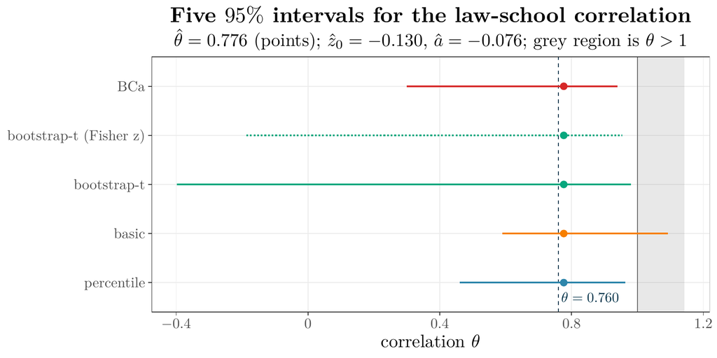

The basic interval $(0.59, 1.09)$ leaves the parameter space. The bootstrap-t $(-0.40, 0.98)$ is erratic at $n = 15$: a resample with a tiny $\widehat{\text{SE}}^*$ produces a huge $t^*$. On Fisher’s scale $\phi(\theta) = \tanh^{-1}\theta$ it shortens to $(-0.19, 0.95)$. The percentile and BCa intervals would not change under $\phi$.

## Coverage in a Skewed Problem

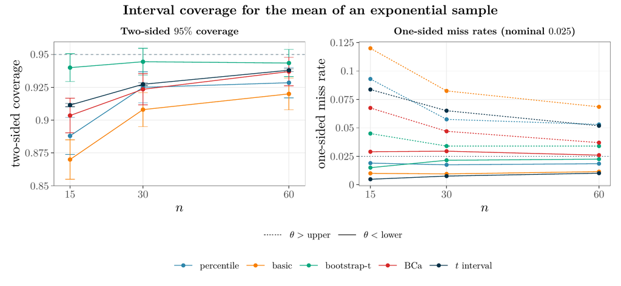

Recall actual against nominal coverage? Nominal 95%, mean of an exponential sample, $n = 15$: bootstrap-t covers $0.940$, BCa $0.903$, percentile $0.888$, basic $0.870$. The percentile interval misses asymmetrically: $0.093$ above against $0.019$ below, each nominally $0.025$.

## The Intervals against the Benchmark

Mean of an exponential sample, $n = 15$, nominal $95\%$:

| Interval | Coverage | $\theta$ below lower limit | $\theta$ above upper limit |
| --- | --- | --- | --- |
| $t$ interval (benchmark) | 0.912 | 0.005 | 0.084 |
| Percentile | 0.888 | 0.019 | 0.093 |
| Basic | 0.870 | 0.010 | 0.120 |
| Bootstrap-t | 0.940 | 0.015 | 0.045 |
| BCa | 0.903 | 0.029 | 0.068 |

The $t$ interval is the benchmark from the coverage act (dark line in the figure). The bootstrap-t recovers most of the gap to $0.95$. BCa is level with the $t$ interval within Monte Carlo error, about $0.008$ for the bootstrap rows. The percentile and basic intervals fall below it.

For a mean the percentile interval has about the length of $\bar X \pm z_{0.975}\sqrt{(n-1)/n}\,S/\sqrt{n}$: normal quantiles in place of $t_{n-1}$ quantiles, and a standard deviation with divisor $n$. At $n = 15$ that is about $12\%$ shorter than the $t$ interval.

## Which Interval to Report

**Which Interval to Report**

For general inference, use BCa: second-order accurate ($O(n^{-1})$ one-sided coverage error), transformation-respecting, no nested resampling. Use the bootstrap-t when $\widehat{\text{SE}}^*$ is available in closed form and the statistic is on a scale where its standard error is stable.

The two examples show both sides of the bootstrap-t. With the closed-form $S^*/\sqrt{n}$ for a mean it has the best coverage of the four. With a jackknife $\widehat{\text{SE}}^*$ for a correlation at $n = 15$ it gives the least usable interval.

# Changing What Is Resampled

## The Parametric Bootstrap

**When you know the model.** If $X_1, \ldots, X_n \sim F_{\theta}$ with parametric family $\{F_{\theta}: \theta \in \Theta\}$:

1. Estimate parameters: $\hat{\theta} = \hat{\theta}(X_1, \ldots, X_n)$
2. Bootstrap from $F_{\hat{\theta}}$ instead of $\hat{F}_n$: generate $X_i^* \sim F_{\hat{\theta}}$ independently
3. Proceed as in the nonparametric bootstrap

**Example: Normal model.** Data: $X_1, \ldots, X_n \sim \Normal(\mu, \sigma^2)$. Estimate $\hat{\mu} = \bar{X}_n$, $\hat{\sigma}^2 = \frac{1}{n-1}\sum_{i=1}^n (X_i - \bar{X}_n)^2$. Generate $X_i^* \sim \Normal(\hat{\mu}, \hat{\sigma}^2)$. More efficient than nonparametric **if** the model is correct.

| Method | Efficiency | Robustness |
| --- | --- | --- |
| Parametric | High | Low (model-dependent) |
| Nonparametric | Lower | High (model-free) |

The parametric bootstrap is Monte Carlo with estimated parameters. When the model is correctly specified, it uses the parametric structure for tighter inference; when the model is wrong, it inherits the misspecification.

## Pairs Bootstrap

**Regression setup.** Model: $Y_i = \mathbf{X}_i^\top\boldsymbol{\beta} + \epsilon_i$ for $i = 1, \ldots, n$; $\mathbf{X}$: the $n \times p$ matrix with rows $\mathbf{X}_i^\top$; $\mathbf{Y} = (Y_1, \ldots, Y_n)^\top$; $^\top$: transpose.

**Pairs bootstrap.**

1. Resample pairs: $(\mathbf{X}_i^*, Y_i^*)$ from $\{(\mathbf{X}_1, Y_1), \ldots, (\mathbf{X}_n, Y_n)\}$
2. Refit model: $\hat{\boldsymbol{\beta}}^* = (\mathbf{X}^{*\top}\mathbf{X}^*)^{-1}\mathbf{X}^{*\top}\mathbf{Y}^*$

**Valid under heteroscedasticity**, no model assumptions on $\epsilon$, preserves the joint distribution of $(\mathbf{X}, Y)$. Changes the design matrix $\mathbf{X}$; can fail if $\mathbf{X}^{*\top}\mathbf{X}^*$ becomes singular.

## Residual Bootstrap

1. Fit model: $\hat{\boldsymbol{\beta}} = (\mathbf{X}^\top\mathbf{X})^{-1}\mathbf{X}^\top\mathbf{Y}$
2. Compute residuals: $\hat{\epsilon}_i = Y_i - \mathbf{X}_i^\top\hat{\boldsymbol{\beta}}$
3. Center: $\tilde{\epsilon}_i = \hat{\epsilon}_i - \bar{\hat{\epsilon}}$
4. Bootstrap: sample $\epsilon_i^*$ from $\{\tilde{\epsilon}_1, \ldots, \tilde{\epsilon}_n\}$
5. Generate: $Y_i^* = \mathbf{X}_i^\top\hat{\boldsymbol{\beta}} + \epsilon_i^*$
6. Refit: $\hat{\boldsymbol{\beta}}^* = (\mathbf{X}^\top\mathbf{X})^{-1}\mathbf{X}^\top\mathbf{Y}^*$

**Keeps $\mathbf{X}$ fixed** (appropriate for designed experiments), often more efficient than pairs. Assumes homoscedasticity and correct model specification.

## Wild Bootstrap

**For heteroscedastic errors.** Multiply residuals by random weights to preserve the variance structure:

1. Compute residuals: $\hat{\epsilon}_i = Y_i - \mathbf{X}_i^\top\hat{\boldsymbol{\beta}}$
2. Generate weights $w_i^*$ from Mammen’s (1993) two-point distribution:
   $$w_i^* = \begin{cases} -(\sqrt{5}-1)/2 & \text{with probability } (\sqrt{5}+1)/(2\sqrt{5}) \\ (\sqrt{5}+1)/2 & \text{with probability } (\sqrt{5}-1)/(2\sqrt{5}) \end{cases}$$
3. Create bootstrap response: $Y_i^* = \mathbf{X}_i^\top\hat{\boldsymbol{\beta}} + w_i^*\hat{\epsilon}_i$
4. Refit: $\hat{\boldsymbol{\beta}}^* = (\mathbf{X}^\top\mathbf{X})^{-1}\mathbf{X}^\top\mathbf{Y}^*$

The weights have $\E[w_i^*] = 0$, $\E[(w_i^*)^2] = 1$, $\E[(w_i^*)^3] = 1$, preserving the first three moments of the residuals.

## Standard Errors under Heteroscedasticity

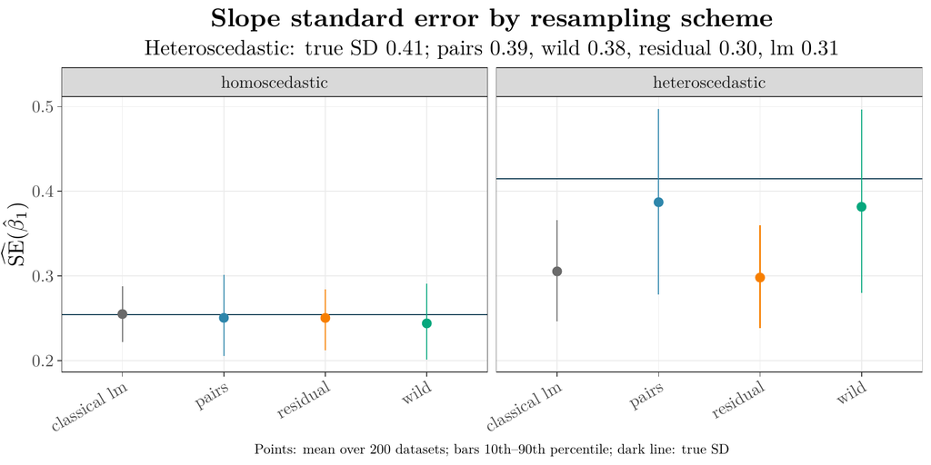

Error standard deviation proportional to $x$: the slope has true SE $0.415$. Averaged over 200 datasets, pairs gives $0.387$ and wild $0.382$, while residual gives $0.298$ and the classical formula $0.305$.

## Bootstrap Hypothesis Testing

**Testing $H_0: \theta = \theta_0$ vs $H_1: \theta \neq \theta_0$.**

1. Compute test statistic $t_{obs}$ from the original data
2. Generate bootstrap samples under $H_0$ (shift data or impose constraint in resampling)
3. Compute $t_1^*, \ldots, t_B^*$ from the constrained bootstrap
4. p-value: $\hat{p} = \frac{1}{B}\sum_{b=1}^B \mathbf{1}\{|t_b^*| \geq |t_{obs}|\}$

**Example: testing $H_0: \mu = \mu_0$.** Shift data: $\tilde{X}_i = X_i - \bar{X}_n + \mu_0$. Bootstrap from $\{\tilde{X}_1, \ldots, \tilde{X}_n\}$. The observed test statistic is $t_{obs} = \bar{X}_n - \mu_0$; the bootstrap statistic is $t_b^* = \bar{X}_b^* - \mu_0$.

**Avoiding Zero P-Values**

Use $\hat{p} = (1 + \sum_{b=1}^B \mathbf{1}\{|t_b^*| \geq |t_{obs}|\})/(B+1)$. This form never returns a zero p-value and corresponds to including the observed test statistic among the bootstrap values.

## What You Actually Do in Practice

1. **One dataset**, one estimate $\hat\theta$.
2. **Resample** $B = 2000$ times and compute $\hat\theta^{*(1)}, \ldots, \hat\theta^{*(B)}$.
3. **Report** $\hat\theta$, $\widehat{\text{SE}}_{\text{boot}}$, and a BCa or bootstrap-t interval, with $B$ and the seed.

**Which theorem licenses which step.**

- The bootstrap principle says the distribution of $\sqrt{n}(\hat\theta^* - \hat\theta)$ under $P^*$ approximates that of $\sqrt{n}(\hat\theta - \theta)$ under $P_F$ for smooth $T$: this licenses step 2.
- The CLT (week 1) says the Monte Carlo error from using $B$ resamples is $O(B^{-1/2})$: this is how $B$ is chosen. A few hundred resamples settle a standard error, and a few thousand settle an interval endpoint.
- Hall’s theorem says the BCa and bootstrap-t intervals have one-sided coverage error $O(n^{-1})$: this licenses step 3.

## Punchlines, and What Comes Next

- The bootstrap replaces $F$ with $\hat F_n$ and runs week-1 Monte Carlo from there. Two errors: statistical (from $\hat F_n$, controlled by $n$) and Monte Carlo (from $B$ resamples, controlled by $B$).
- It works for smooth functionals of $F$. For non-smooth statistics like the sample maximum, the discrete support of $\hat F_n$ prevents the bootstrap from approximating a continuous limit.
- The choice of interval matters: BCa and bootstrap-t give $O(n^{-1})$ one-sided coverage error; percentile and basic give $O(n^{-1/2})$.
- What you resample determines what you assume: pairs for heteroscedasticity, residuals for efficiency under homoscedasticity, wild when neither holds, parametric when the model is trusted.

The bootstrap is week-1 Monte Carlo with $\hat F_n$ in place of $F$. It asks for a smooth statistic and enough resamples. What remains is the choice of interval, and that choice decides the accuracy.

Next week: the jackknife. The bootstrap’s deterministic, linear cousin, and the source of the acceleration constant $\hat a$ that BCa needs.